# PISA 2012 Math Gender Gap Exploration

## by Maryna Misyura

## Investigation Overview

> In this investigation, I wanted to look at how students' beliefs, attitudes and anxieties toward mathematics are related to math performance and gender of students.

## Dataset Overview

> This dataset is a PISA 2012 survey of students' skills and knowledge in mathematics, reading and science. Also background information about 15-year-old students was collected in addition to test results. There are 485490 students in the dataset from 68 different countries.

## Distribution test scores by Gender

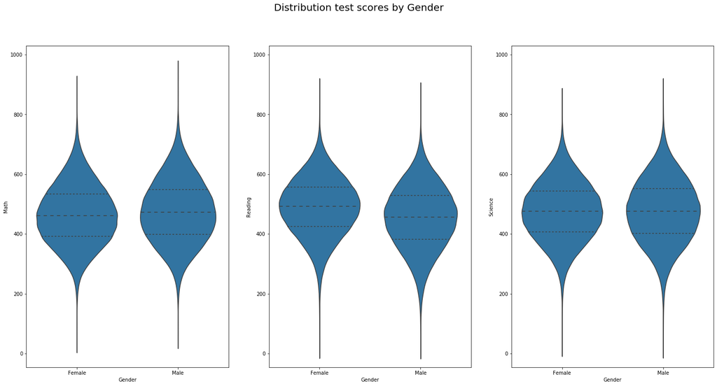

```python
fig, axes = plt.subplots(nrows=1, ncols=3, figsize=(25,12))
plt.title('Distribution test scores by Gender')
plt.subplot(1, 3, 1)
ax1 = sb.violinplot(data = pisa, x = 'Gender', y = 'Math_score', color = base_color, inner = 'quartile')
plt.ylabel('Math')
plt.subplot(1, 3, 2)
sb.violinplot(data = pisa, x = 'Gender', y = 'Reading_score', color = base_color, inner = 'quartile')
plt.ylabel('Reading')
plt.ylim(ax1.get_ylim());
plt.subplot(1, 3, 3)
sb.violinplot(data = pisa, x = 'Gender', y = 'Science_score', color = base_color, inner = 'quartile')
plt.ylabel('Science')
plt.ylim(ax1.get_ylim());
fig.suptitle('Distribution test scores by Gender',fontsize=20);
#plt.show()
#fig.tight_layout()
```

## Personal beliefs about math

> In 2012 PISA investigated a range of self-beliefs: Mathematics interest and enjoyment, mathematics anxiety (feelings of stress and helplessness when dealing with mathematics), mathematics self-concept (students’ beliefs in their own mathematics abilities). Across all counties:
> - 49% Females and 57% Males enjoy math
> - 67% Females and 57% Males have some degree of Math anxiety
> - 43% Females and 56% Males perceive themselves competent in mathematics
> - Females are less likely than Males to be among the highest-achieving students in mathematics

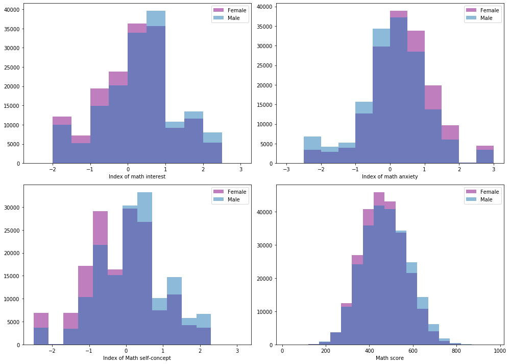

```python
fig, axes = plt.subplots(nrows=2, ncols=2, figsize=(14,10))
plt.subplot(2, 2, 1)
#Mathematics interest and enjoyment
binsize = 0.5
bins = np.arange(-2.5, 3 + binsize, binsize)
plt.hist(data = pisa.query('Gender =="Female"'), x = 'Math_interest', bins = bins, color='purple', alpha=0.5, label='Female')
plt.hist(data = pisa.query('Gender =="Male"'), x = 'Math_interest', bins = bins, color=base_color, alpha=0.5, label='Male')
plt.xlabel('Index of math interest')
plt.legend()
plt.grid(False)
plt.subplot(2, 2, 2)
#Math anxiety - feelings of stress and helplessness when dealing with mathematics
bins = np.arange(-3, 3.5, binsize)
plt.hist(data = pisa.query('Gender =="Female"'), x = 'Math_anxiety', bins = bins, color='purple', alpha=0.5, label='Female')
plt.hist(data = pisa.query('Gender =="Male"'), x = 'Math_anxiety', bins = bins, color=base_color, alpha=0.5, label='Male')
plt.xlabel('Index of math anxiety')
plt.legend()
plt.subplot(2, 2, 3)
#Math self-concept - perceived competence in mathematics
binsize = 0.4
bins = np.arange(-2.5, 3.5, binsize)
plt.hist(data = pisa.query('Gender =="Female"'), x = 'Math_self_concept', bins = bins, color='purple', alpha=0.5, label='Female')
plt.hist(data = pisa.query('Gender =="Male"'), x = 'Math_self_concept', bins = bins, color=base_color, alpha=0.5, label='Male')
plt.xlabel('Index of Math self-concept')
plt.legend()
plt.subplot(2, 2, 4)
#Math_score
binsize = 50
bins = np.arange(pisa['Math_score'].min(), pisa['Math_score'].max()+binsize, binsize)
plt.hist(data = pisa.query('Gender =="Female"'), x = 'Math_score', bins = bins, color='purple', alpha=0.5, label='Female')
plt.hist(data = pisa.query('Gender =="Male"'), x = 'Math_score', bins = bins, color=base_color, alpha=0.5, label='Male')
plt.xlabel('Math score')
plt.legend()
fig.tight_layout()
```

## Correlation between average Math performance and Index of Math anxiety

> I looked at the relationship between math performance and Index of Math anxiety. I found out that there is a negative correlation(r = -0.36) between them across all countries.  
> Also negative correlation can be seen on the next slide between averages of both variables for each country  
> There is also weak correlation between math self-concept and math performance.

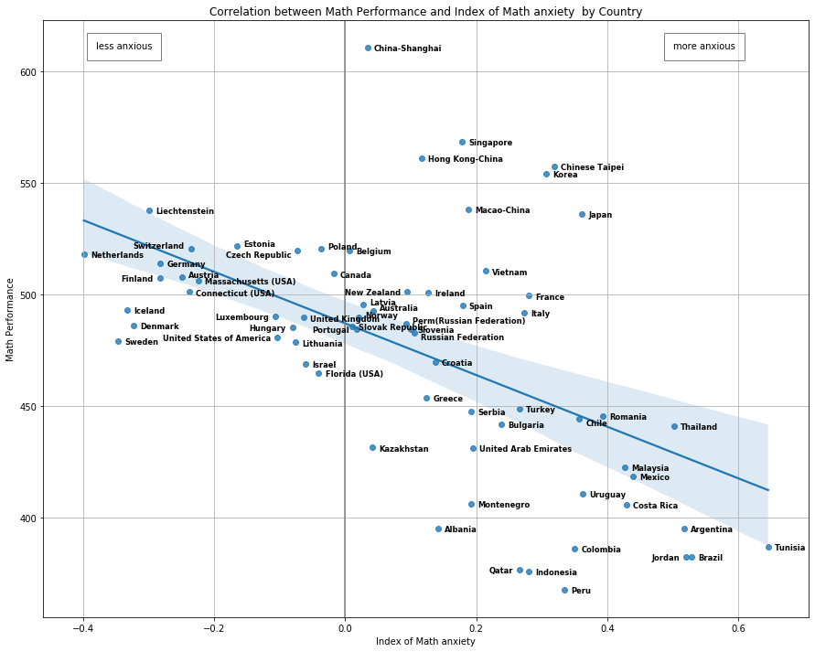

```python
#Correlation between math_score and Math_anxiety  by Country
df= pisa.groupby('Country').mean()[['Math_anxiety', 'Math_score']]
df = df.reset_index()
p=sb.regplot(data=df, x='Math_anxiety', y='Math_score',  marker="o", color=base_color)
p.figure.set_size_inches(15, 12)
plt.grid(True)
plt.axvline(x=0, color = 'grey')
counties_left = ['Qatar', 'Jordan','Hungary','Portugal', 'New Zealand', 'Switzerland', 'Czech Republic', 'Luxembourg', 'United States of America', 'Finland']
counties_top = ['Estonia', 'Poland','Latvia','Australia', 'Norway', 'Perm(Russian Federation)', 'Switzerland', 'Austria']
counties_bottom = ['Czech Republic','Russian Federation', 'Chile']
for line in range(0,df.shape[0]):
    hr = 'left'
    offset = 0.01
    ver = 'center_baseline'
    if df.Country[line] in counties_left:
        hr = 'right'
        offset = - 0.01
        #ver = 'bottom'
    if df.Country[line] in counties_top:
        ver = 'baseline'
    if df.Country[line] in counties_bottom:
        ver = 'top'
    p.text(df.Math_anxiety[line]+offset, df.Math_score[line], df.Country[line], horizontalalignment=hr, verticalalignment=ver, size='small', color='black', weight='semibold')
p.text(-0.38, 610, r'less anxious', fontsize=10,
        bbox={'facecolor': 'white', 'alpha': 0.5, 'pad': 10});
p.text(0.5, 610, r'more anxious', fontsize=10,
        bbox={'facecolor': 'white', 'alpha': 0.5, 'pad': 10});
plt.title('Correlation between Math Performance and Index of Math anxiety  by Country');
plt.xlabel('Index of Math anxiety');
plt.ylabel('Math Performance');
```

## Correlation between Math performance and Index of Math anxiety

> Earlier we saw that on average boys slightly overperform girls in math.  
> Girls have higher levels of mathematics anxiety which negatively correlated (r=-0.36) with math performance.  
> Girls also reported lower levels of mathematics self_concept (their perceived competence in mathematics).

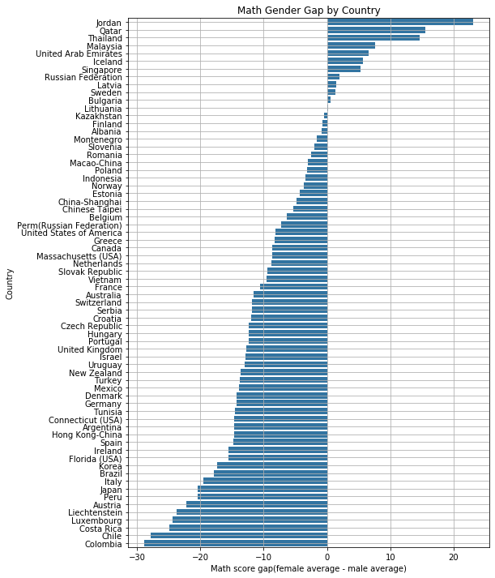

```python
#plot gender gap
plt.figure(figsize=[8, 12])
sb.barplot(data = df_diff.sort_values('diff_math', ascending=False), y ='Country', x = 'diff_math', color=base_color) ;
plt.grid(True)
plt.title('Math Gender Gap by Country');
plt.xlabel('Math score gap(female average - male average)');
```

## Math anxiety levels and Math self-concept (belief in their own abilities)

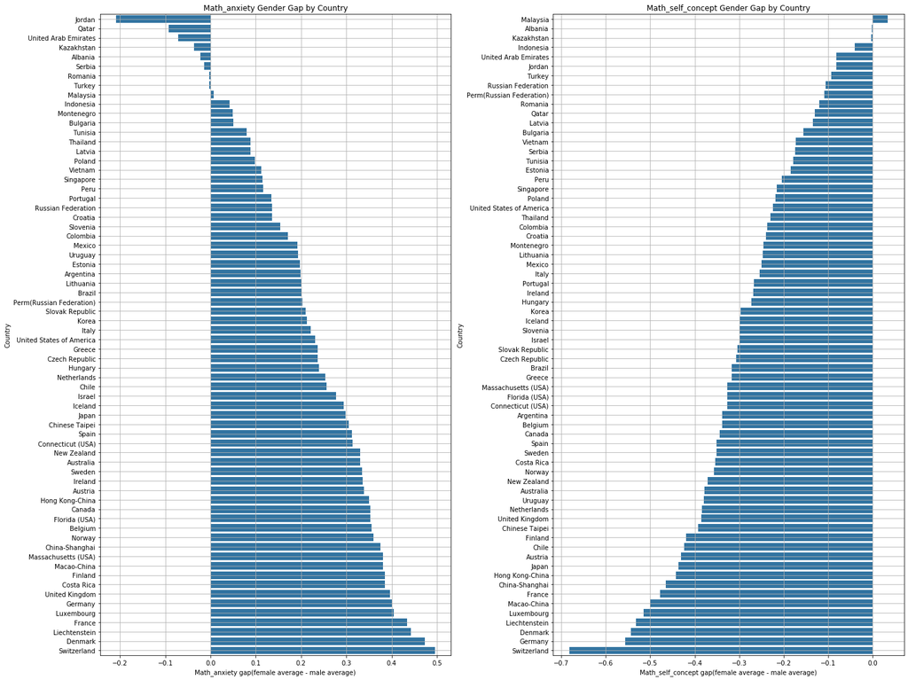

```python
#plot Math_anxiety and Math_self_concept gender gap for each country
fig, ax = plt.subplots(ncols=2, figsize = [20,15]);
plt.subplot(1, 2, 1)
sb.barplot(data = df_diff.sort_values('diff_anx', ascending=True), y ='Country', x = 'diff_anx', color=base_color) ;
plt.grid(True)
plt.title('Math_anxiety Gender Gap by Country');
plt.xlabel('Math_anxiety gap(female average - male average)');
plt.subplot(1, 2, 2)
sb.barplot(data = df_diff.sort_values('diff_self', ascending=False), y ='Country', x = 'diff_self', color=base_color) ;
plt.grid(True)
plt.title('Math_self_concept Gender Gap by Country');
plt.xlabel('Math_self_concept gap(female average - male average)');
fig.tight_layout()
```

## Correlation between Math Gender Gap and Math Anxiety Gender Gap by Country

> This shows us a negative relationship between differences in average math scores of boys and girls and differences in average levels of math anxiety across all countries in PISA 2012.  
> By decreasing differences in math anxiety and math anxiety overall we can improve math performance.

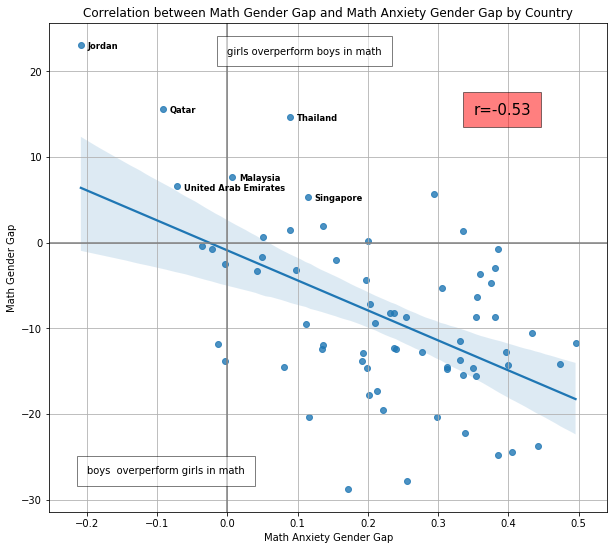

```python
p=sb.regplot(data=df_diff, x='diff_anx',y='diff_math',  marker="o", color=base_color);
p.figure.set_size_inches(10, 9)
plt.grid(True)
plt.axvline(x=0, color = 'grey')
plt.axhline(y=0, color = 'grey')
counties_top5 = ['Qatar', 'Jordan','Thailand','Malaysia', 'United Arab Emirates','Singapore']
hr = 'left'
offset = 0.01
ver = 'center_baseline'
for line in range(0,df_diff.shape[0]):
    if df_diff.Country[line] in counties_top5:
        p.text(df_diff.diff_anx[line]+offset, df_diff.diff_math[line], df_diff.Country[line], horizontalalignment=hr, verticalalignment=ver, size='small', color='black', weight='semibold')
p.text(0.35, 15, r'r=' + '{:0.2f}'.format(df_diff['diff_math'].corr(df_diff['diff_anx'])), fontsize=15,
        bbox={'facecolor': 'red', 'alpha': 0.5, 'pad': 10});
p.text(0, 22, r'girls overperform boys in math', fontsize=10,
        bbox={'facecolor': 'white', 'alpha': 0.5, 'pad': 10});
p.text(-0.2, -27, r'boys  overperform girls in math', fontsize=10,
        bbox={'facecolor': 'white', 'alpha': 0.5, 'pad': 10});
plt.title('Correlation between Math Gender Gap and Math Anxiety Gender Gap by Country');
plt.xlabel('Math Anxiety Gender Gap');
plt.ylabel('Math Gender Gap');
```

## Correlation between Math Gender Gap and Math self-concept Gender Gap by Country

> Correlation between math performance gender gap and math self-concept gender gap is smaller (0.49).  
> More girls would believe they are good at math, the smaller will be the average math performance difference between genders.

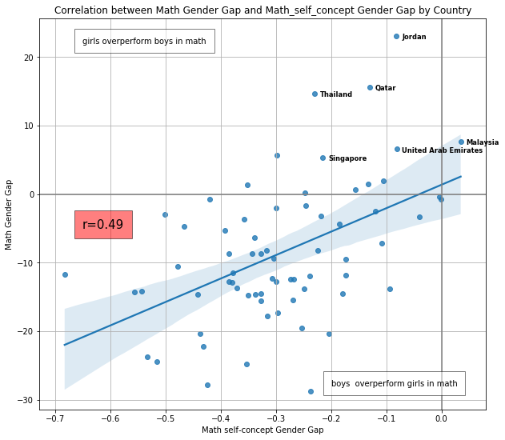

```python
#Math_self_concept
p=sb.regplot(data=df_diff, x='diff_self',y='diff_math',  marker="o", color=base_color);
p.figure.set_size_inches(10, 9)
plt.grid(True)
plt.axvline(x=0, color = 'grey')
plt.axhline(y=0, color = 'grey')
counties_top5 = ['Qatar', 'Jordan','Thailand','Malaysia', 'United Arab Emirates', 'Singapore']
hr = 'left'
offset = 0.01
ver = 'center_baseline'
for line in range(0,df_diff.shape[0]):
    if df_diff.Country[line] in counties_top5:
        p.text(df_diff.diff_self[line]+offset, df_diff.diff_math[line], df_diff.Country[line], horizontalalignment=hr, verticalalignment=ver, size='small', color='black', weight='semibold')
p.text(-0.65, -5, r'r=' + '{:0.2f}'.format(df_diff['diff_math'].corr(df_diff['diff_self'])), fontsize=15,
       bbox={'facecolor': 'red', 'alpha': 0.5, 'pad': 10});
p.text(-0.65, 22, r'girls overperform boys in math', fontsize=10,
        bbox={'facecolor': 'white', 'alpha': 0.5, 'pad': 10});
p.text(-0.2, -28, r'boys  overperform girls in math', fontsize=10,
        bbox={'facecolor': 'white', 'alpha': 0.5, 'pad': 10});
plt.title('Correlation between Math Gender Gap and Math_self_concept Gender Gap by Country');
plt.xlabel('Math self-concept Gender Gap');
plt.ylabel('Math Gender Gap');
```